# Informe 4: Análisis de datos

Carmen Lebrero Cia

5/11/2020

```r
if (!requireNamespace("BiocManager", quietly=TRUE))
    install.packages("BiocManager")
BiocManager::install("TCGAbiolinks")
library(TCGAbiolinks)
library(dplyr)
library(SummarizedExperiment)
library(DT)
```

# Archivos de datos clínicos

Si utilizamos la función `str()` sobre `ClinicKIRC2` (datos clínicos de TCGA-KIRC) observamos que se trata de un archivo Dataframe con 537 observaciones y 66 variables.

```r
str(ClinicKIRC2)
```

```
## 'data.frame':    537 obs. of  66 variables:
##  $ bcr_patient_barcode                       : chr  "TCGA-3Z-A93Z" "TCGA-6D-AA2E" "TCGA-A3-3306" "TCGA-A3-3307" ...
##  $ additional_studies                        : Factor w/ 2 levels "","TCGAFPPP": 1 1 1 1 1 1 1 1 1 1 ...
##  $ tumor_tissue_site                         : Factor w/ 1 level "Kidney": 1 1 1 1 1 1 1 1 1 1 ...
##  $ histological_type                         : Factor w/ 1 level "Kidney Clear Cell Renal Carcinoma": 1 1 1 1 1 1 1 1 1 1 ...
##  $ other_dx                                  : Factor w/ 4 levels "No","Yes","Yes, History of Prior Malignancy",..: 1 1 1 2 1 1 1 1 1 1 ...
##  $ gender                                    : Factor w/ 2 levels "FEMALE","MALE": 2 1 2 2 1 2 2 2 2 2 ...
##  $ vital_status                              : Factor w/ 3 levels "","Alive","Dead": 2 2 2 2 2 3 3 2 2 2 ...
##  $ days_to_birth                             : int  -25205 -25043 -24569 -24315 -28287 -21183 -21556 -20931 -24803 -25699 ...
##  $ days_to_last_known_alive                  : int  NA NA NA NA NA NA NA NA NA NA ...
##  $ days_to_death                             : int  NA NA NA NA NA 1191 735 NA NA NA ...
##  $ days_to_last_followup                     : int  4 135 1120 1436 16 NA NA 1493 1491 1130 ...
##  $ race_list                                 : Factor w/ 4 levels "","ASIAN","BLACK OR AFRICAN AMERICAN",..: 3 3 4 1 4 1 3 4 1 4 ...
##  $ tissue_source_site                        : Factor w/ 20 levels "3Z","6D","A3",..: 1 2 3 3 3 3 3 3 3 3 ...
##  $ patient_id                                : chr  "A93Z" "AA2E" "3306" "3307" ...
```

[output cut: 52 more lines]

De entre todas las variables las más interesantes parecen ser `bcr_patient_barcode`, `vital_status` o `stage_event_pathologic_stage`. Vamos a encontrar los índices de cada variable en el dataframe y podemos hacer un dataframe más pequeño.

```r
grep("bcr_patient_barcode", colnames(ClinicKIRC2))
```

```
## [1] 1
```

```r
grep("vital_status", colnames(ClinicKIRC2))
```

```
## [1] 7
```

```r
grep("stage_event_pathologic_stage", colnames(ClinicKIRC2))
```

```
## [1] 59
```

```r
ClinicS <- ClinicKIRC2[,c(1,7,59)]
head(ClinicS)
```

|  | bcr_patient_barcode | vital_status | stage_event_pathologic_stage |
| --- | --- | --- | --- |
| 1 | TCGA-3Z-A93Z | Alive | Stage I |
| 2 | TCGA-6D-AA2E | Alive | Stage I |
| 3 | TCGA-A3-3306 | Alive | Stage I |
| 4 | TCGA-A3-3307 | Alive | Stage III |
| 5 | TCGA-A3-3308 | Alive | Stage III |
| 6 | TCGA-A3-3311 | Dead | Stage I |

Vamos a ver si existen missing values con `is.na()`.

```r
sum(is.na(ClinicS))
```

```
## [1] 0
```

Observamos que no tenemos ningún NA en este Dataset, por lo que tenemos datos de nuestra variable de interés para los 537 pacientes del estudio TCGA-KIRC.

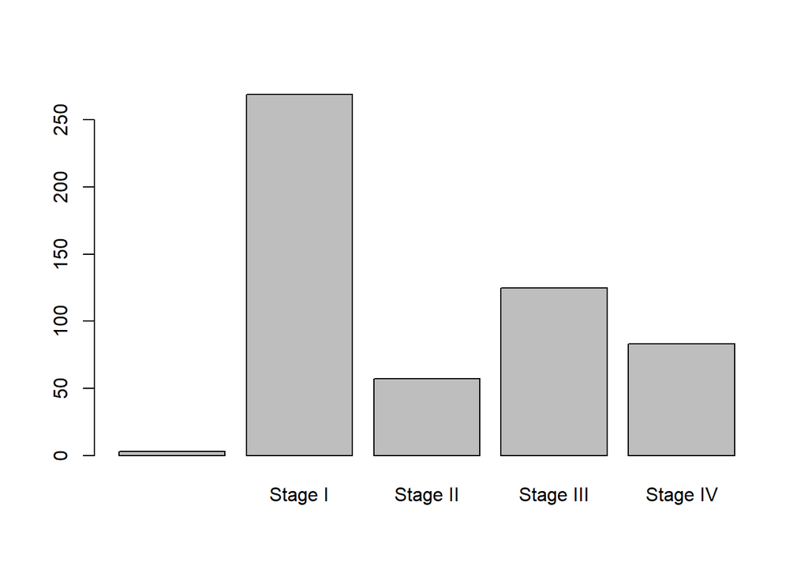

```r
plot(ClinicKIRC2$stage_event_pathologic_stage)
```

Podemos obtener el número exacto de pacientes con la función `summmary()`.

```r
summary(ClinicKIRC2$stage_event_pathologic_stage)
```

```
##             Stage I  Stage II Stage III  Stage IV
##         3       269        57       125        83
```

Esta clasificación por estadíos se refiere a lo siguiente a un método de agrupación de los pacientes según una serie de características de los tumores como la localización y el tamaño del tumor (T), si se observan ganglios linfáticos cerca (N) o si hay metástasis (M).

- **Estadío 0**. Describe cáncer “in situ” que están localizados en el lugar de origen y no se han esparcido a tejidos cercanos. Son tumores fácilmente curables que se pueden quitar con una cirugía.
- **Estadío 1**. Se trata de un tumor pequeño que no se ha extendido de forma muy profunda a tejidos colindantes ni a los ganglios linfáticos. A veces se le denomina cáncer temprano.
- **Estadíos II y III**. Estos dos estadíos indican tumores más grandes que se han extendido de forma más profunda a tejidos y que pueden haber llegado a los ganglios linfáticos pero no a otros órganos.
- **Estadío IV**. Este estadío significa que el cáncer se ha extendido a otros órganos. También conocido como cáncer metastásico avanzado.

También podemos obtener información acerca de los fallecimientos de nuestra muestra. Y observamos que 372 siguen vivos y 162 han fallecido. Volvemos a ver 3 muestras que no están catalogadas en ninguno de estos dos grupos, debemos ver si esas muestras, aunque hayamos hecho anteriormente la búsqueda de missing values, no contienen información.

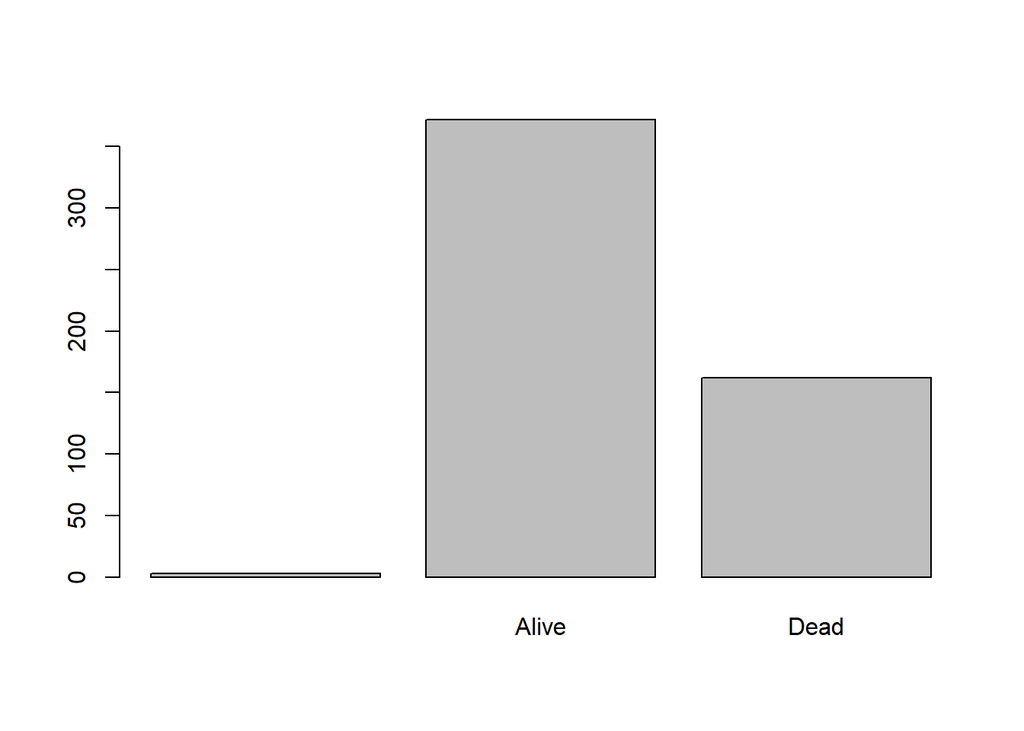

```r
plot(ClinicKIRC2$vital_status)
```

```r
summary(ClinicKIRC2$vital_status)
```

```
##       Alive  Dead
##     3   372   162
```

Otro análisis interesante sería saber cuántos fallecidos hay según el estadío del tumor.

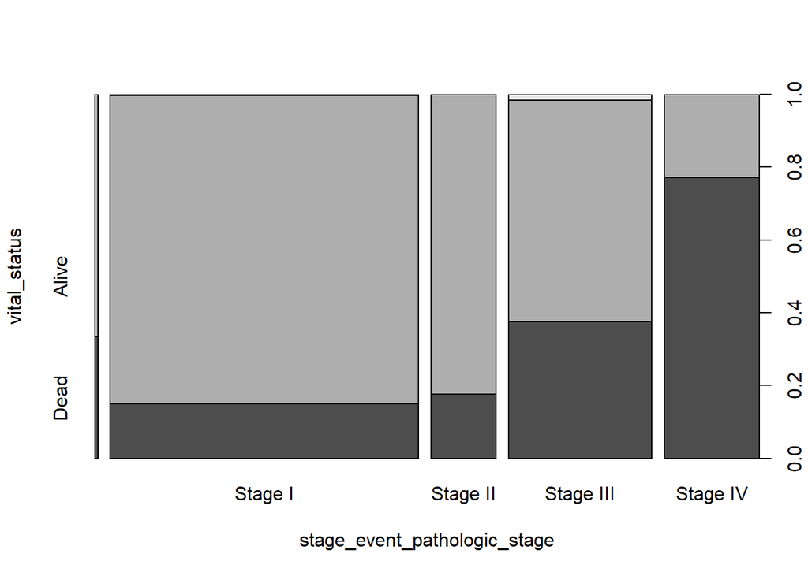

```r
plot(vital_status ~ stage_event_pathologic_stage, data = ClinicKIRC2)
```

**Fase I (n=269)**

Fallecidos

```r
length(subset(ClinicKIRC2$patient_id , ClinicKIRC2$vital_status == "Dead" & ClinicKIRC2$stage_event_pathologic_stage == "Stage I"))
```

```
## [1] 40
```

Vivos

```r
length(subset(ClinicKIRC2$patient_id , ClinicKIRC2$vital_status == "Alive" & ClinicKIRC2$stage_event_pathologic_stage == "Stage I"))
```

```
## [1] 228
```

**Fase II (n=57)**

Fallecidos

```r
length(subset(ClinicKIRC2$patient_id , ClinicKIRC2$vital_status == "Dead" & ClinicKIRC2$stage_event_pathologic_stage == "Stage II"))
```

```
## [1] 10
```

Vivos

```r
length(subset(ClinicKIRC2$patient_id , ClinicKIRC2$vital_status == "Alive" & ClinicKIRC2$stage_event_pathologic_stage == "Stage II"))
```

```
## [1] 47
```

**Fase III (n=125)**

Fallecidos

```r
length(subset(ClinicKIRC2$patient_id , ClinicKIRC2$vital_status == "Dead" & ClinicKIRC2$stage_event_pathologic_stage == "Stage III"))
```

```
## [1] 47
```

Vivos

```r
length(subset(ClinicKIRC2$patient_id , ClinicKIRC2$vital_status == "Alive" & ClinicKIRC2$stage_event_pathologic_stage == "Stage III"))
```

```
## [1] 76
```

**Fase IV (n=83)**

Fallecidos

```r
length(subset(ClinicKIRC2$patient_id , ClinicKIRC2$vital_status == "Dead" & ClinicKIRC2$stage_event_pathologic_stage == "Stage IV"))
```

```
## [1] 64
```

Vivos

```r
length(subset(ClinicKIRC2$patient_id , ClinicKIRC2$vital_status == "Alive" & ClinicKIRC2$stage_event_pathologic_stage == "Stage IV"))
```

```
## [1] 19
```

Vamos a buscar esos pacientes que no tienen vital_status asignado:

```r
subset(ClinicKIRC2$bcr_patient_barcode , ClinicKIRC2$vital_status != "Dead" & ClinicKIRC2$vital_status != "Alive")
```

```
## [1] "TCGA-BP-4326" "TCGA-BP-4329" "TCGA-BP-4334"
```

Y ver si estos tres son los mismos que no tienen asignada la fase del tumor:

```r
subset(ClinicKIRC2$bcr_patient_barcode , ClinicKIRC2$stage_event_pathologic_stage != "Stage I" & ClinicKIRC2$stage_event_pathologic_stage != "Stage II" & ClinicKIRC2$stage_event_pathologic_stage != "Stage III" & ClinicKIRC2$stage_event_pathologic_stage != "Stage IV")
```

```
## [1] "TCGA-B4-5838" "TCGA-BP-4798" "TCGA-MM-A563"
```

No son los mismos pacientes los que no tienen etiqueta para vital_status y para la Fase del cancer. Creamos dos Datasets. `ClinicSVital` sin los tres pacientes que no tienen etiqueta para Vital_status y `ClinicSStage` sin los pacientes que no tienen etiqueta para Stage. Además se crearán dos cadenas de caracteres con los barcodes de cada Dataframe.

```r
ClinicSVital <- subset(ClinicS, ClinicS$bcr_patient_barcode != "TCGA-BP-4326" & ClinicS$bcr_patient_barcode != "TCGA-BP-4329" & ClinicS$bcr_patient_barcode != "TCGA-BP-4334")
```

```r
ClinicSStage <- subset(ClinicS, ClinicS$bcr_patient_barcode != "TCGA-B4-5838" & ClinicS$bcr_patient_barcode != "TCGA-BP-4798" & ClinicS$bcr_patient_barcode != "TCGA-MM-A563")
```

Si elegimos como variable a modelar `vital_status`se tratará de un problema de clasificaicón binaria. Mientras que si elegimos el estadío del tumor, sería un problema de clasificación multiclase.

# Datos de Expresión Génica

Vamos a explorar nuestros datos de Expresión Génica `ExpGenKIRC3`. Observamos que se trata de un archivo `RangedSummarizedExperiment`, para tratar este tipo de archivos podemos seguir la siguiente guía: https://www.bioconductor.org/packages/release/bioc/vignettes/SummarizedExperiment/inst/doc/SummarizedExperiment.html.

## Introducción

La clase `SummarizedExperiment` se usa para llenar matrices rectangulares de resultados experimentales producidos normalmente en experimentos de secuenciación o microarrays. Cada objeto almacena observaciones de una o más muestras, junto con metadatos adicionales que describen obsevaciones (características) y muestras (fenotipos).

Un aspecto clave de la clase `SummarizedExperiment` es la coordinación de los metadatos y los ensayos cuando se realizan subagrupaciones o subconjuntos. Por ejemplo, si quieres excluir una muestra se puede hacer en los metadatos y en los ensayos en una única operación, lo que asegura que los metadatos y los datos observados permanezcan sincronizados.

## Anatomía de SummarizedExperiment

El paquete `SummarizedExperiment` contiene dos clases: `SummarizedExperiment` y `RangedSummarizedExperiment`.

`SummarizedExperiment` es un contenedor similar a una matriz donde las filas representan características de interés (por ejemplo: genes, transcritos, exones, etc.) y las columnas representan las muestras. Los objetos contienen uno o más ensayos, cada uno representado por un objeto matriz de número u otro modo. Las filas del objeto `SummarizedExperiment` representan características de interés. La información acerca de estas características está almacenada en un objeto Dataframe, accesible usando la función `rowData()`. Cada fila del Dataframe aporta información de la característica en la fila correspondiente del objeto `SummarizedExperiment`. Las columnas del Datafram representan diferentes atributos de las características de interés como IDs de genes o transcritos.

`RangedSummarizedExperiment` es el “hijo” de la clase `SummarizedExperiment`, lo que significaa que todos los métodos de `SummarizedExperiment`también funcionan sobre `RangedSummarizedExperiment`.

La diferencia fundamental entre las dos clases es que las filas de `RangedSummarizedExperiment`representan rangos genómicos de interés en vez de un Dataframe de carcterísticas. Los rangos de `RangedSummarizedExperiment`se describen en el objeto `GRanges`o `GRangesList`, accesible utilizando la función `rowRanges()`.

## Assays

```r
library(SummarizedExperiment)
se <- ExpGenKIRC3
se
```

```
## class: RangedSummarizedExperiment
## dim: 19947 606
## metadata(1): data_release
## assays(2): raw_count scaled_estimate
## rownames(19947): A1BG|1 A2M|2 ... TMED7-TICAM2|100302736
##   LOC100303728|100303728
## rowData names(4): gene_id entrezgene ensembl_gene_id
##   transcript_id.transcript_id_TCGA-B0-5694-01A-11R-1541-07
## colnames(606): TCGA-B0-5694-01A-11R-1541-07
##   TCGA-CJ-4637-01A-02R-1325-07 ... TCGA-CJ-4871-01A-01R-1305-07
##   TCGA-AK-3460-01A-02R-1277-07
## colData names(70): barcode patient ... paper_mRNA_cluster
##   paper_microRNA_cluster
```

Para recuperar los datos a partir del experimento a partir de un objeto `SummarizedExperiment` se puede utilizar `assays()`. Un objeto puede tener múltiples dataset de ensayos a los que se puede acceder usando el operador `$`. En nuestro caso tenemos dos datasets: `raw_count` y `scaled_estimate`. Partiremos desde el archivo `raw_count` para realizar nuestro análisis.

```r
assays(se)$raw_count[1:3,1:4]
```

```
##        TCGA-B0-5694-01A-11R-1541-07 TCGA-CJ-4637-01A-02R-1325-07
## A1BG|1                        36.00                        87.66
## A2M|2                      71105.61                     47586.92
## NAT1|9                       111.00                       295.00
##        TCGA-CZ-4860-01A-01R-1305-07 TCGA-B0-4706-01A-01R-1503-07
## A1BG|1                        60.00                       180.09
## A2M|2                      39077.92                     69333.51
## NAT1|9                       208.00                       140.00
```

```r
rowRanges(se)
```

```
## GRanges object with 19947 ranges and 4 metadata columns:
##                          seqnames              ranges strand |      gene_id
##                             <Rle>           <IRanges>  <Rle> |  <character>
##                   A1BG|1    chr19   58856544-58864865      - |         A1BG
##                    A2M|2    chr12     9220260-9268825      - |          A2M
##                   NAT1|9     chr8   18027986-18081198      + |         NAT1
##                  NAT2|10     chr8   18248755-18258728      + |         NAT2
##              SERPINA3|12    chr14   95058395-95090983      + | RP11-986E7.7
##                      ...      ...                 ...    ... .          ...
##   LOC100302401|100302401     chr1 178060643-178063119      - |   RASAL2-AS1
##   LOC100302640|100302640     chr3 106555658-106959488      - |    LINC00882
##     NCRNA00182|100302692     chrX   73183790-73513409      - |          FTX
##   TMED7-TICAM2|100302736     chr5 114914339-114961876      - |       TICAM2
##   LOC100303728|100303728     chrX 118599997-118603061      - |  SLC25A5-AS1
##                          entrezgene ensembl_gene_id
##                           <integer>     <character>
##                   A1BG|1          1 ENSG00000121410
##                    A2M|2          2 ENSG00000175899
##                   NAT1|9          9 ENSG00000171428
##                  NAT2|10         10 ENSG00000156006
##              SERPINA3|12         12 ENSG00000273259
##                      ...        ...             ...
##   LOC100302401|100302401  100302401 ENSG00000224687
##   LOC100302640|100302640  100302640 ENSG00000242759
##     NCRNA00182|100302692  100302692 ENSG00000230590
##   TMED7-TICAM2|100302736  100302736 ENSG00000243414
##   LOC100303728|100303728  100303728 ENSG00000224281
##                          transcript_id.transcript_id_TCGA-B0-5694-01A-11R-1541-07
##                                                                       <character>
##                   A1BG|1                                    uc002qsd.3,uc002qsf.1
##                    A2M|2                                   uc001qvj.1,uc001qvk...
##                   NAT1|9                                   uc003wyq.2,uc003wyr...
##                  NAT2|10                                               uc003wyw.1
##              SERPINA3|12                                   uc001ydo.3,uc001ydp...
##                      ...                                                      ...
##   LOC100302401|100302401                                    uc001gln.1,uc001glo.1
##   LOC100302640|100302640                                    uc003dwf.3,uc011bhk.1
##     NCRNA00182|100302692                                    uc004ebr.1,uc010nlq.1
##   TMED7-TICAM2|100302736                                    uc003krd.2,uc003kre.2
##   LOC100303728|100303728                                    uc004ere.1,uc004erg.1
##   -------
##   seqinfo: 24 sequences from an unspecified genome; no seqlengths
```

## Columnas (datos de las muestras)

Se puede acceder a los metadatos que describen las muestras usando ``colData()`, y es un Dataframe que puede almacenar cualquier número de columna.

```r
colData(se)
```

Se puede acceder a estos metadatos usando `$`, lo que hace más sencillo sustraer un objeto entero dado un fenotipo. Por ejemplo, podemos extraer todas las muestras que tengan una etiqueta para el estado vital:

```r
se[, se$vital_status == "Dead" | se$vital_status == "Alive"]
```

```
## class: RangedSummarizedExperiment
## dim: 19947 606
## metadata(1): data_release
## assays(2): raw_count scaled_estimate
## rownames(19947): A1BG|1 A2M|2 ... TMED7-TICAM2|100302736
##   LOC100303728|100303728
## rowData names(4): gene_id entrezgene ensembl_gene_id
##   transcript_id.transcript_id_TCGA-B0-5694-01A-11R-1541-07
## colnames(606): TCGA-B0-5694-01A-11R-1541-07
##   TCGA-CJ-4637-01A-02R-1325-07 ... TCGA-CJ-4871-01A-01R-1305-07
##   TCGA-AK-3460-01A-02R-1277-07
## colData names(70): barcode patient ... paper_mRNA_cluster
##   paper_microRNA_cluster
```

Vamos a buscar Missing values para la etiqueta de Fase del tumor para lo cual utilizaremos el siguiente código:

```r
which(is.na(se$ajcc_pathologic_stage))
```

```
## [1] 128 290 460
```

```r
se$patient[c(128,190,460)]
```

```
## [1] "TCGA-BP-4798" "TCGA-BP-4338" "TCGA-MM-A563"
```

## Preprocesado: Exploración, Control de Calidad y Normalización de datos TCGA

Seguiremos el Pipeline mostrado en: https://bioconductor.org/packages/release/bioc/vignettes/TCGAbiolinks/inst/doc/analysis.html#TCGAanalyze:_Analyze_data_from_TCGA

### Control de calidad

https://bmcbioinformatics.biomedcentral.com/articles/10.1186/s12859-020-3399-8

```r
KIRCnaseq_CorOutliers <- TCGAanalyze_Preprocessing(ExpGenKIRC3)
```